# IODS course project

Giovanni Marchi

# Introduction to Open Data Science - Course Project

# About the project

*Write a short description about the course and add a link to your GitHub repository here. This is an R Markdown (.Rmd) file so you should use R Markdown syntax.*

```r
# This is a so-called "R chunk" where you can write R code.

date()
```

```
## [1] "Mon Dec  4 19:40:05 2023"
```

The course started quite well and *smoothly*. I like the introduction by professor Kimmo and generally everything looks quite scheduled and organised. From the course I expect to improve my bioinformatic and data science related knowledge. I already have quite a bit of $R$ skills but I’m sure I will improve those as well with this course: I really like programming and $R$ is a quite cool language. For sure, it shines when used with Rstudio. I actually didn’t know about the Git communication!  
I heard about this course from a colleague of mine.  
Here’s the link to my [GitHub repository](https://github.com/marchigg/IODS-project.git%7D).

# Regression and model validation

*Describe the work you have done this week and summarize your learning.*

- Describe your work and results clearly.
- Assume the reader has an introductory course level understanding of writing and reading R code as well as statistical methods.
- Assume the reader has no previous knowledge of your data or the more advanced methods you are using.

```r
date()
```

```
## [1] "Mon Dec  4 19:40:05 2023"
```

```r
# load the GGally and ggplot2 libraries
library(GGally)
library(ggplot2)
```

### Description of the data

```r
# read students2014 dataset after manipulation (from data wrangling)
data <- read.csv("analysis.csv", header = T, row.names = 1)

# explore the dataset
str(data)
```

```
## 'data.frame':    166 obs. of  7 variables:
##  $ gender  : chr  "F" "M" "F" "M" ...
##  $ Age     : int  53 55 49 53 49 38 50 37 37 42 ...
##  $ Attitude: num  3.7 3.1 2.5 3.5 3.7 3.8 3.5 2.9 3.8 2.1 ...
##  $ deep    : num  3.58 2.92 3.5 3.5 3.67 ...
##  $ stra    : num  3.38 2.75 3.62 3.12 3.62 ...
##  $ surf    : num  2.58 3.17 2.25 2.25 2.83 ...
##  $ Points  : int  25 12 24 10 22 21 21 31 24 26 ...
```

```r
dim(data)
```

```
## [1] 166   7
```

The dataset is composed of 166 lines and 7 columns.  
This dataset is a subset of a bigger one reporting the result of student survey. Each observation (i.e. row) is a student and the variables (i.e. columns) represent statistics of the students. Variables are:

- *gender*, categorical (M or F), reporting gender of student.
- *age*, numeric, reporting age of student.
- *attitude*, numeric, reporing a sum of 10 questions related to students attitude towards statistics, each measured on the [Likert scale](https://en.wikipedia.org/wiki/Likert_scale) (1-5)
- *deep*, numeric, is a combination variable of 12 deep learning questions.
- *stra*, numeric, is a combination variable of 8 strategic learning questions.
- *surf*, numeric, is a combination variable of 12 “surface” questions.
- *Points*, numeric, reports the exam points.

### Visualization of the data

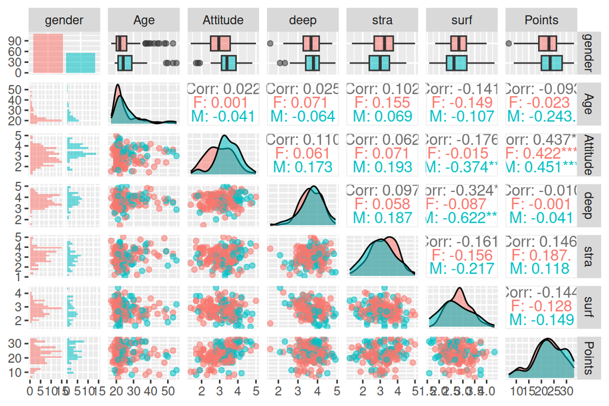

```r
# visualize all of the variables and relationships in a single plot
ggpairs(data, mapping = aes(col = gender, alpha = 0.3),
        lower = list(combo = wrap("facethist", bins = 20)))
```

From the visualization we can appreciate that the distributions of the variables does not differ much when the gender difference is taken into account. Only *age* variable has more outliers for females than males.  
Two variable pairs show significant correlation: positive for *attitude* and *points*, and negative for *surf* and *deep*. Interestingly for the latter case (*surf* vs *deep*), the negative correlation is significant only for males.

### Multiple regression

```r
# fit a model where points is the outcome variable and attitude, stra and surf are
# the explanatory variables
fit <- lm(Points ~ Attitude + stra + surf, data = data)
# summary of fitted model
summary(fit)
```

```
##
## Call:
## lm(formula = Points ~ Attitude + stra + surf, data = data)
##
## Residuals:
##      Min       1Q   Median       3Q      Max
## -17.1550  -3.4346   0.5156   3.6401  10.8952
##
## Coefficients:
##             Estimate Std. Error t value Pr(>|t|)
## (Intercept)  11.0171     3.6837   2.991  0.00322 **
## Attitude      3.3952     0.5741   5.913 1.93e-08 ***
## stra          0.8531     0.5416   1.575  0.11716
## surf         -0.5861     0.8014  -0.731  0.46563
## ---
## Signif. codes:  0 '***' 0.001 '**' 0.01 '*' 0.05 '.' 0.1 ' ' 1
##
## Residual standard error: 5.296 on 162 degrees of freedom
## Multiple R-squared:  0.2074, Adjusted R-squared:  0.1927
## F-statistic: 14.13 on 3 and 162 DF,  p-value: 3.156e-08
```

As the three explanatory variables I selected *attitude*, *stra* and *surf* since they are that shows the highest absolute correlation with the target variable.  
From the summary we can get some information about the model:

- **Estimate** is the intercept (b0) and the b1 coefficient estimates associated to each predictor variable.
- **Std.Error** is the standard error of the coefficient estimates, representing the accuracy of the coefficients.
- **t value** represents the t-statistic
- **p-value** shows the significance of the relationship of the target variable.

Looking at the individual explanatory variables, only *attitude*, with a pvalue of ~1.9e-8, seems to give an important contribution to the model. The other variables don’t show a significant pvalue. So, I’m removing them from the model.

```r
# fit a model where points is the outcome variable and attitude and stra are the
# explanatory variables
fit_2 <- lm(Points ~ Attitude + stra, data = data)
# summary of fitted model
summary(fit_2)
```

```
##
## Call:
## lm(formula = Points ~ Attitude + stra, data = data)
##
## Residuals:
##      Min       1Q   Median       3Q      Max
## -17.6436  -3.3113   0.5575   3.7928  10.9295
##
## Coefficients:
##             Estimate Std. Error t value Pr(>|t|)
## (Intercept)   8.9729     2.3959   3.745  0.00025 ***
## Attitude      3.4658     0.5652   6.132 6.31e-09 ***
## stra          0.9137     0.5345   1.709  0.08927 .
## ---
## Signif. codes:  0 '***' 0.001 '**' 0.01 '*' 0.05 '.' 0.1 ' ' 1
##
## Residual standard error: 5.289 on 163 degrees of freedom
## Multiple R-squared:  0.2048, Adjusted R-squared:  0.1951
## F-statistic: 20.99 on 2 and 163 DF,  p-value: 7.734e-09
```

```r
# fit a model where points is the outcome variable and attitude is the explanatory
# variable.
fit_1 <- lm(Points ~ Attitude, data = data)
# summary of fitted model
summary(fit_1)
```

```
##
## Call:
## lm(formula = Points ~ Attitude, data = data)
##
## Residuals:
##      Min       1Q   Median       3Q      Max
## -16.9763  -3.2119   0.4339   4.1534  10.6645
##
## Coefficients:
##             Estimate Std. Error t value Pr(>|t|)
## (Intercept)  11.6372     1.8303   6.358 1.95e-09 ***
## Attitude      3.5255     0.5674   6.214 4.12e-09 ***
## ---
## Signif. codes:  0 '***' 0.001 '**' 0.01 '*' 0.05 '.' 0.1 ' ' 1
##
## Residual standard error: 5.32 on 164 degrees of freedom
## Multiple R-squared:  0.1906, Adjusted R-squared:  0.1856
## F-statistic: 38.61 on 1 and 164 DF,  p-value: 4.119e-09
```

### Interpretation of multiple regression

```r
# summary of fitted model with only attitude as explanatory variable
summary(fit_1)
```

```
##
## Call:
## lm(formula = Points ~ Attitude, data = data)
##
## Residuals:
##      Min       1Q   Median       3Q      Max
## -16.9763  -3.2119   0.4339   4.1534  10.6645
##
## Coefficients:
##             Estimate Std. Error t value Pr(>|t|)
## (Intercept)  11.6372     1.8303   6.358 1.95e-09 ***
## Attitude      3.5255     0.5674   6.214 4.12e-09 ***
## ---
## Signif. codes:  0 '***' 0.001 '**' 0.01 '*' 0.05 '.' 0.1 ' ' 1
##
## Residual standard error: 5.32 on 164 degrees of freedom
## Multiple R-squared:  0.1906, Adjusted R-squared:  0.1856
## F-statistic: 38.61 on 1 and 164 DF,  p-value: 4.119e-09
```

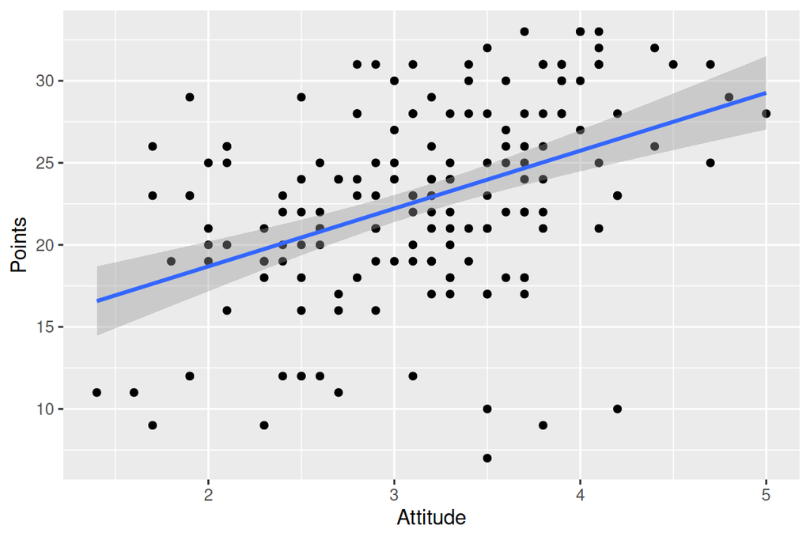

```r
# plot the two variables
ggplot(data = data, aes(x = Attitude, y = Points)) +
    geom_point() +
    geom_smooth(method = "lm")
```

The explanatory variable *attitude* is significant associated with the target variable *points* (pvalue is significant, 4.12e-09). Considering the formula $yi = β0 + β1xi$, from the summary we can appreciate that our model shows $β0$ = 11.6372 and $β1$ = 3.5255. This means that for each +1 of the explanatory variable, x, the target variable, y, increases of +3.5255.

The fitted model has a *Multiple R-squared* of 0.1906, meaning that the ~19% of the variable of the target variable is explained by the explanatory variable.

### Diagnostic plots

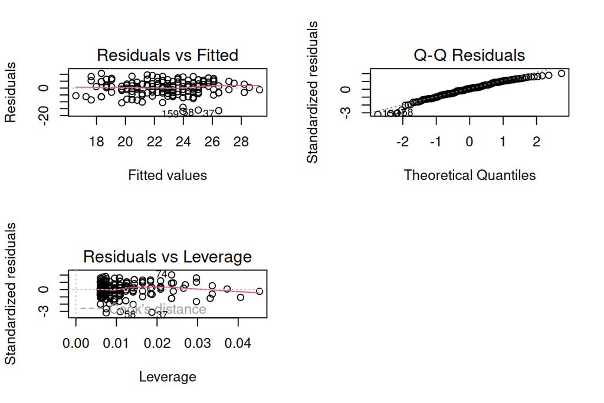

```r
# produce Residuals vs Fitted values, Normal QQ-plot and Residuals vs Leverage
# diagnostic plots.
par(mfrow = c(2,2))
plot(fit_1, which = c(1,2,5))
```

- **Residual vs Fitted plot** displays the residuals vs the fitted values showing if the residuals have a non-linear pattern. If the values equally spread around the horizontal line without showing any pattern it means that non-linear relationships are not present into the data.
  - It is the case for our model: the values are equally spread (with few outliers though) and there is no evidence for any problem in the model.
- **Normal QQ-plot** shows if the residuals are normally distributed: if it’s so, they are distributed on the dashed line.
  - Again, this plot doesn’t show any issue. The values are quite well placed along the line.
- **Residuals vs Laverage plot** displays Standardized residuals vs leverage. In this plot values should not outside the Cook’s distance 1.
  - Values are not outside the Cook’s distance so no issues detected.

# Logistic regression

*Describe the work you have done this week and summarize your learning.*

- Describe your work and results clearly.
- Assume the reader has an introductory course level understanding of writing and reading R code as well as statistical methods.
- Assume the reader has no previous knowledge of your data or the more advanced methods you are using.

```r
date()
```

```
## [1] "Mon Dec  4 19:40:14 2023"
```

```r
# load libraries
library(ggplot2)
library(dplyr)
library(boot)
library(tidyr)
```

### Description of the data

```r
# load the alc dataset
alc <- read.table("data/alc.csv", sep = '\t', header = T)
# print out the names of the variables and describe the data set briefly
colnames(alc)
```

```
##  [1] "school"     "sex"        "age"        "address"    "famsize"
##  [6] "Pstatus"    "Medu"       "Fedu"       "Mjob"       "Fjob"
## [11] "reason"     "guardian"   "traveltime" "studytime"  "schoolsup"
## [16] "famsup"     "activities" "nursery"    "higher"     "internet"
## [21] "romantic"   "famrel"     "freetime"   "goout"      "Dalc"
## [26] "Walc"       "health"     "failures"   "paid"       "absences"
## [31] "G1"         "G2"         "G3"         "alc_use"    "high_use"
```

The dataset is the result of the merging of two identical questionnaires including student grades, demographic, social and school related features related to secondary school student alcohol consumption in Portugal. The two original questionnaires report the performance in two distinct subjects: mathematics and Portuguese language.  
The two questionnaires were merged using the common variables (columns); the questionnaire-specific columns were merged by calculating the mean of the ones with numeric data and by reporting the results of the mathematics questionnaire of the ones with non numeric data.

### Making hypothesis

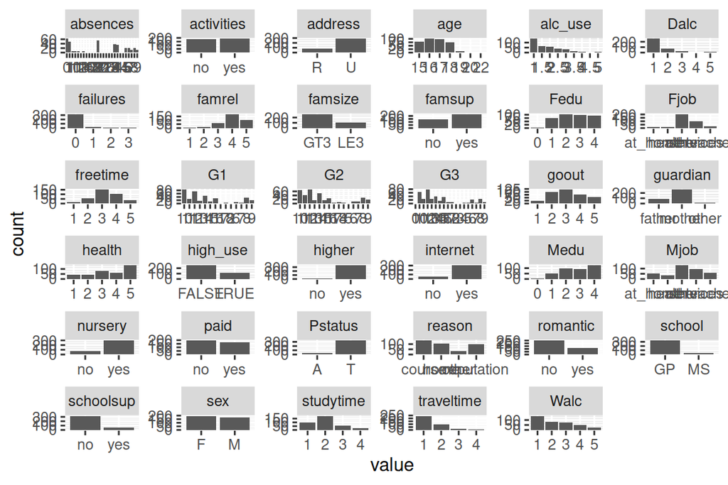

```r
# draw a bar plot of each variable
gather(alc) %>% ggplot(aes(value)) + facet_wrap("key", scales = "free") + geom_bar()
```

Looking at the variables, here are the four hypotheses for possible alcohol consupton relationships:

- *sex* is an important variable since previous studies reported that males teenagers/young adults show a higher alcohol consuption compareed to females of the same age.
- *age* is important too since people around 18-22 y/o consume more alcohol than younger peers.
- *studytime* can be associated with alcohol consumption since students who spend more time studying are less prone to abuse alcohol.
- finally *famsup* can be associated too. Students with more family educational support are maybe less prone to abuse alcohol.

### Distributions of chosen variables

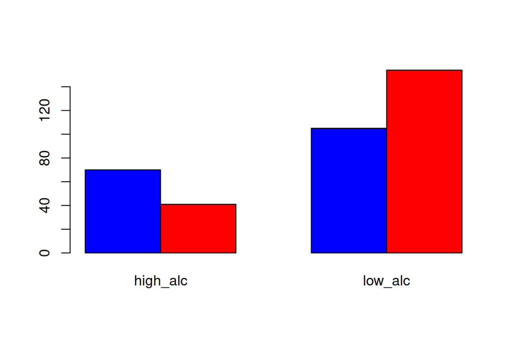

```r
# sex
data <- data.frame(sex = c("M", "F"),
           high_alc = c(nrow(alc[alc$sex == "M" & alc$high_use == TRUE,]),
                        nrow(alc[alc$sex == "F" & alc$high_use == TRUE,])),
           low_alc = c(nrow(alc[alc$sex == "M" & alc$high_use == FALSE,]),
                       nrow(alc[alc$sex == "F" & alc$high_use == FALSE,])))
rownames(data) <- data[,1]
data <- data[,-1]
barplot(as.matrix(data) , beside=T,col=c("blue" , "red") , ylab="")
```

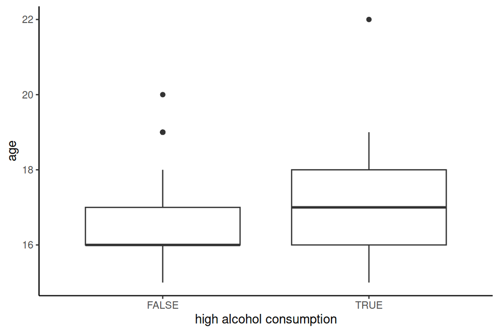

```r
# age
ggplot(alc, aes(x = high_use, y = age)) +
  geom_boxplot() + xlab("high alcohol consumption") + ylab("age") +
  theme_classic()
```

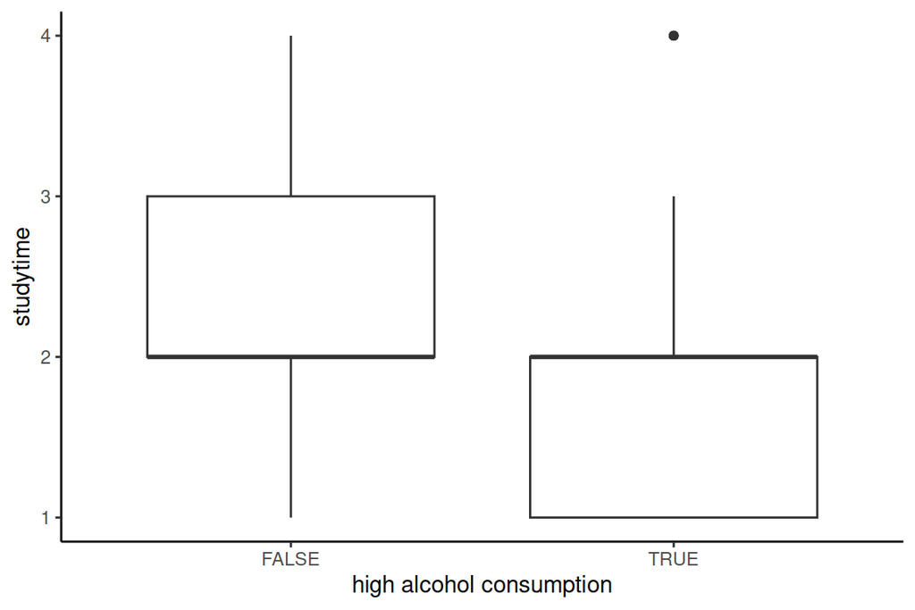

```r
# studytime
ggplot(alc, aes(x = high_use, y = studytime)) +
  geom_boxplot() + xlab("high alcohol consumption") + ylab("studytime") +
  theme_classic()
```

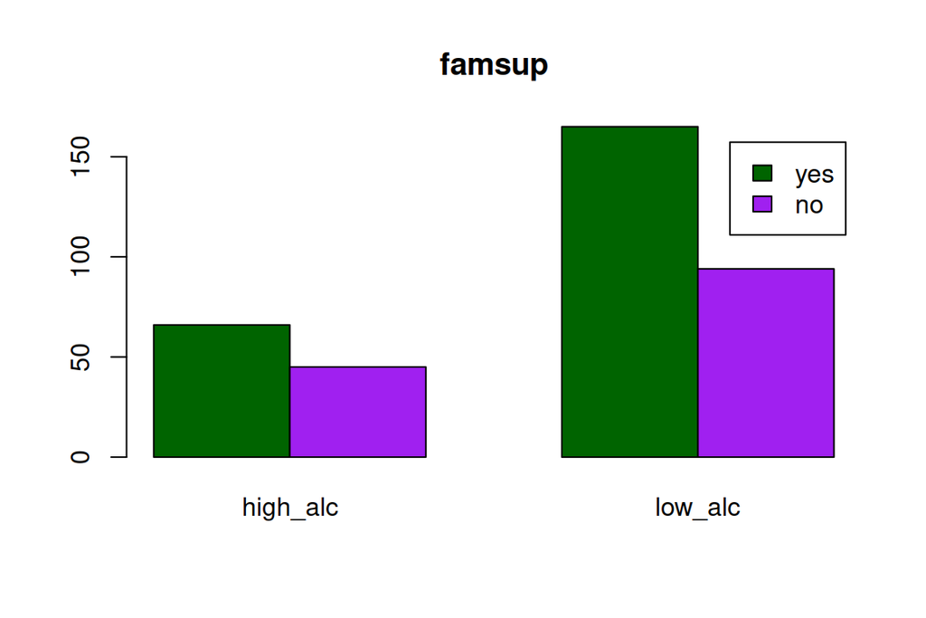

```r
# famsup
data <- data.frame(famsup = c("yes", "no"),
           high_alc = c(nrow(alc[alc$famsup == "yes" & alc$high_use == TRUE,]),
                        nrow(alc[alc$famsup == "no" & alc$high_use == TRUE,])),
           low_alc = c(nrow(alc[alc$famsup == "yes" & alc$high_use == FALSE,]),
                       nrow(alc[alc$famsup == "no" & alc$high_use == FALSE,])))
rownames(data) <- data[,1]
data <- data[,-1]
barplot(as.matrix(data) , legend.text = T, beside=T,col=c("darkgreen" , "purple"),
        ylab="", main= "famsup")
```

According to my hypothesis, male students seem to have a higher alcohol consumption compared to female peers. The same goes for age: older students seem to have a higher alcohol consumption. Interestingly, studytime looks a very important predictor of alcohol abuse, even more than sex. The effect of famsup on the consumption is hard to establish from the plot: it seems that an effect is actually present but it is not as significant as for the other predictors.

### Logistic regression

```r
fit <- glm(high_use ~ sex + age + studytime + famsup , data = alc, family = "binomial")
summary(fit)
```

```
##
## Call:
## glm(formula = high_use ~ sex + age + studytime + famsup, family = "binomial",
##     data = alc)
##
## Coefficients:
##             Estimate Std. Error z value Pr(>|z|)
## (Intercept)  -3.8395     1.7471  -2.198  0.02797 *
## sexM          0.7268     0.2502   2.905  0.00367 **
## age           0.2120     0.1015   2.088  0.03681 *
## studytime    -0.5076     0.1614  -3.144  0.00167 **
## famsupyes     0.1393     0.2501   0.557  0.57747
## ---
## Signif. codes:  0 '***' 0.001 '**' 0.01 '*' 0.05 '.' 0.1 ' ' 1
##
## (Dispersion parameter for binomial family taken to be 1)
##
##     Null deviance: 452.04  on 369  degrees of freedom
## Residual deviance: 420.92  on 365  degrees of freedom
## AIC: 430.92
##
## Number of Fisher Scoring iterations: 4
```

```r
OR <- coef(fit) %>% exp
# compute confidence intervals (CI)
CI <- confint(fit) %>% exp
CI
```

```
##                    2.5 %    97.5 %
## (Intercept) 0.0006667136 0.6396151
## sexM        1.2698828036 3.3925294
## age         1.0150125081 1.5128364
## studytime   0.4341702473 0.8188937
## famsupyes   0.7072097008 1.8883245
```

```r
# print out the odds ratios with their confidence intervals
cbind(OR, CI)
```

```
##                     OR        2.5 %    97.5 %
## (Intercept) 0.02150485 0.0006667136 0.6396151
## sexM        2.06838548 1.2698828036 3.3925294
## age         1.23609527 1.0150125081 1.5128364
## studytime   0.60193318 0.4341702473 0.8188937
## famsupyes   1.14948947 0.7072097008 1.8883245
```

### Prediction

```r
fit1 <- glm(high_use ~ sex + age + studytime, data = alc, family = "binomial")
summary(fit1)
```

```
##
## Call:
## glm(formula = high_use ~ sex + age + studytime, family = "binomial",
##     data = alc)
##
## Coefficients:
##             Estimate Std. Error z value Pr(>|z|)
## (Intercept)  -3.6554     1.7142  -2.132  0.03297 *
## sexM          0.7072     0.2474   2.858  0.00426 **
## age           0.2054     0.1008   2.037  0.04161 *
## studytime    -0.4972     0.1601  -3.105  0.00190 **
## ---
## Signif. codes:  0 '***' 0.001 '**' 0.01 '*' 0.05 '.' 0.1 ' ' 1
##
## (Dispersion parameter for binomial family taken to be 1)
##
##     Null deviance: 452.04  on 369  degrees of freedom
## Residual deviance: 421.24  on 366  degrees of freedom
## AIC: 429.24
##
## Number of Fisher Scoring iterations: 4
```

```r
# predict() the probability of high_use
probabilities <- predict(fit1, type = "response")
# add the predicted probabilities to 'alc'
alc <- mutate(alc, probability = probabilities)
# use the probabilities to make a prediction of high_use
alc <- mutate(alc, prediction = probability > 0.5)
# tabulate the target variable versus the predictions
table(high_use = alc$high_use, prediction = alc$prediction)
```

```
##         prediction
## high_use FALSE TRUE
##    FALSE   244   15
##    TRUE     92   19
```

```r
# define a loss function (mean prediction error)
loss_func <- function(class, prob) {
  n_wrong <- abs(class - prob) > 0.5
  mean(n_wrong)
}

# call loss_func to compute the average number of wrong predictions in the (training) data
loss_func(class = alc$high_use, prob = alc$probability)
```

```
## [1] 0.2891892
```

My model has a average number of wrong predictions of ~0.29, that is quite good. Compared to a simple guessing strategy, taht would result in a wrong prediction value of 0.5, it is much better.  
Anyway, the goodness of a prediction tool is highly study-specific and many evaluation criteria should be taken into account. In summary my model is not bad but not perfect either and a better predictors choice could be made.

### 10-fold cross validation

```r
# K-fold cross-validation
cv <- cv.glm(data = alc, cost = loss_func, glmfit = fit1, K = 10)

# average number of wrong predictions in the cross validation
cv$delta[1]
```

```
## [1] 0.3054054
```

# Dimensionality reduction techniques

*Describe the work you have done this week and summarize your learning.*

- Describe your work and results clearly.
- Assume the reader has an introductory course level understanding of writing and reading R code as well as statistical methods.
- Assume the reader has no previous knowledge of your data or the more advanced methods you are using.

```r
date()
```

```
## [1] "Mon Dec  4 19:40:18 2023"
```

```r
# load libraries
library(tibble)
library(readr)
library(GGally)
library(FactoMineR)
library(tidyr)
library(dplyr)
```

### Description of the data

```r
# load the Human data
human <- read_csv("https://raw.githubusercontent.com/KimmoVehkalahti/Helsinki-Open-Data-Science/master/datasets/human2.csv")
```

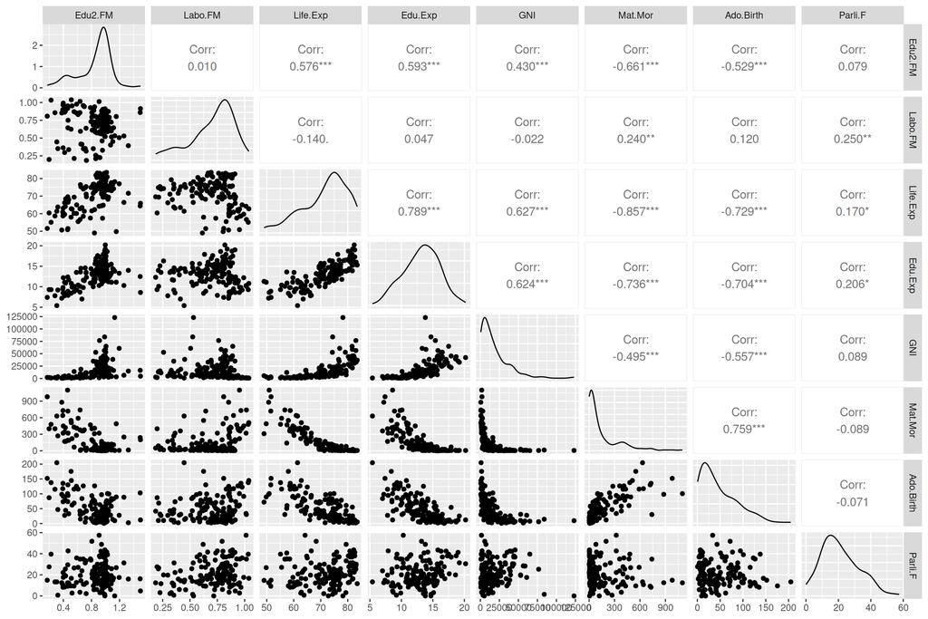

```r
# move the country names to rownames
human <- column_to_rownames(human, "Country")
# visualize the 'human' variables
ggpairs(human, progress = FALSE)
```

The dataset contains information about 8 qualaity-of-life variables for the different countries (155).  
Looking at the pairs plot, we can appreciate that many variables have a correlation with each other. 7 comparisons underline a strong significant positive correlation between variables, namely **Life.Ep** vs **Edu2.FM**, **Edu.Exp** vs **Edu2.FM**, **GNI** vs **Edu2.FM**, **Edu.Exp** vs **Life.Exp**, **GNI** vs **Life.Exp**, **GNI** vs **Edu.Exp** and **Ado.Birth** vs **Mat.Mort**. So, out of these 7 positive correlations, 3 of them include correlation with **Edu2.FM**: that suggests how countries with a high proportion of males with at least secondary education have a higher Life expectancy at birth, Expected years of schooling and Gross National Income per capita.  
The other way around, 8 comparisons show a strong significant negative correlation between variables, namely **Mat.Mort** vs **Edu2.FM**, **Ado.Birth** vs **Edu2.FM**, **Mat.Mort** vs **Life.Exp**, **Ado.Birth** vs **Life.Exp**, **Mat.Mort** vs **Edu.Exp**, **Ado.Birth** vs **Edu.Exp**, **Mat.Mort** vs **GNI** and **Ado.Birth** vs **GNI**.

### PCA with non-scaled data

```r
# perform PCA
pca_res <- prcomp(human)
# variability captured by the PCs
s <- summary(pca_res)
s
```

```
## Importance of components:
##                              PC1      PC2   PC3   PC4   PC5   PC6    PC7    PC8
## Standard deviation     1.854e+04 185.5219 25.19 11.45 3.766 1.566 0.1912 0.1591
## Proportion of Variance 9.999e-01   0.0001  0.00  0.00 0.000 0.000 0.0000 0.0000
## Cumulative Proportion  9.999e-01   1.0000  1.00  1.00 1.000 1.000 1.0000 1.0000
```

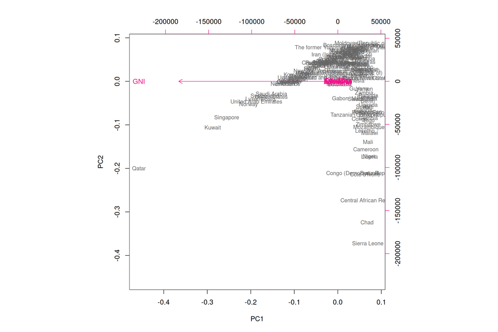

```r
# biplot
biplot(pca_res, cex = c(0.8, 1), col = c("grey40", "deeppink2"))
```

### PCA with scaled data

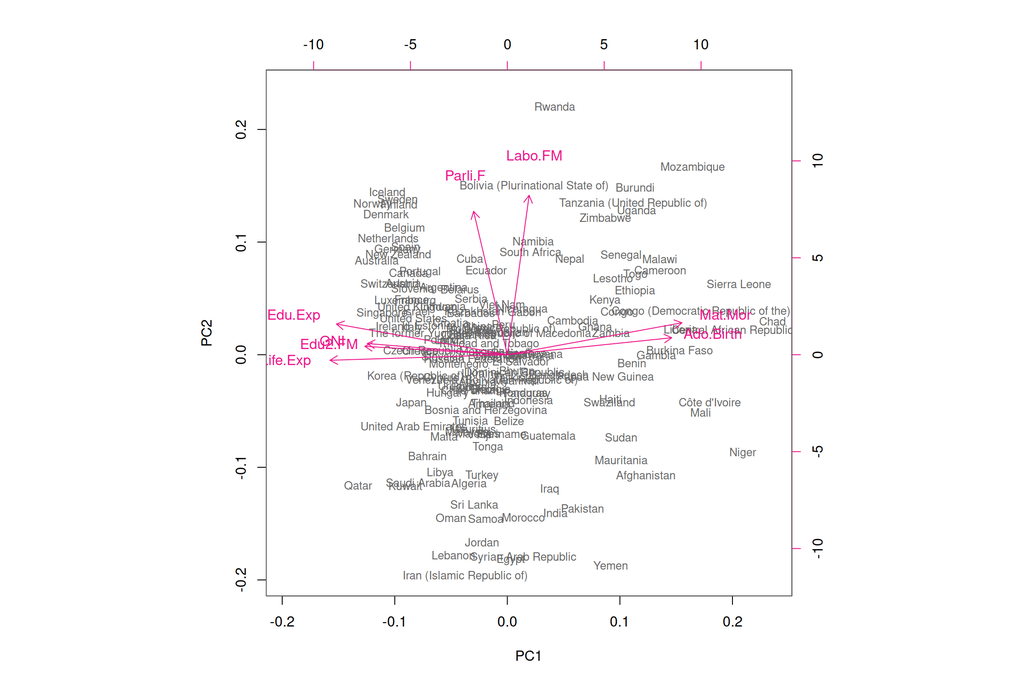

```r
# scale human data
human_scaled <- scale(human)
# perform PCA
pca_res_scaled <- prcomp(human_scaled)
# variability captured by the PCs
s_scaled <- summary(pca_res_scaled)
# biplot
biplot(pca_res_scaled, cex = c(0.8, 1), col = c("grey40", "deeppink2"))
```

This second PCA looks much better. In fact, the first PCA, resulting from a non-scaled data-frame, is not very informative since the variable **GNI**, which has values much higher compared to the other ones, is the only visible, making the other ones (and the Country names) barely recognizable.  
After scaling (second PCA), all the variables are in the same range, making any interpretation of the result possible.

### Interpretation of PCs

From the scaled PCA plot, I can appreciate that the PC1 (x acis), accounts for the variability of most of the variables: **Mat.Mort**, **Abo.Birth** on the positive sign, and **Edu.FM**, **Edu.Exp**, **GNI** and **Life.Exp** on the negative sign. The PC2 (y axis), on the other hand accounts for the variability of **Parli.F** and **Labo.FM**, both on the positive sign.  
Focusing on the PC1, it’s interesting to appreciate that the variables describing development in different aspects of society, like life expentancy, GNI or educational expectancy points towards the negative side, meaning that more developed countries are placed on the left of the plot (of course, positive and negative does not mean anything here, I’m just stating that “good” variables goes to the left). Taken that into account, we can see that both maternal mortality ratio and Adolescent birth rate point towards right, so the opposite compared to the “good” measurements I’ve mentioned before. If that was is not surprising for maternal mortality ratio, the presence of Adolescent birth rate in the opposite direction compared to the “good” measures underlines that people in developed countries tend to have children later than in less developed ones.

### MCA on tea dataset

```r
# laod tea dataset
tea <- read.csv("https://raw.githubusercontent.com/KimmoVehkalahti/Helsinki-Open-Data-Science/master/datasets/tea.csv",
                stringsAsFactors = TRUE)
dim(tea)
```

```
## [1] 300  36
```

```r
str(tea)
```

```
## 'data.frame':    300 obs. of  36 variables:
##  $ breakfast       : Factor w/ 2 levels "breakfast","Not.breakfast": 1 1 2 2 1 2 1 2 1 1 ...
##  $ tea.time        : Factor w/ 2 levels "Not.tea time",..: 1 1 2 1 1 1 2 2 2 1 ...
##  $ evening         : Factor w/ 2 levels "evening","Not.evening": 2 2 1 2 1 2 2 1 2 1 ...
##  $ lunch           : Factor w/ 2 levels "lunch","Not.lunch": 2 2 2 2 2 2 2 2 2 2 ...
##  $ dinner          : Factor w/ 2 levels "dinner","Not.dinner": 2 2 1 1 2 1 2 2 2 2 ...
##  $ always          : Factor w/ 2 levels "always","Not.always": 2 2 2 2 1 2 2 2 2 2 ...
##  $ home            : Factor w/ 2 levels "home","Not.home": 1 1 1 1 1 1 1 1 1 1 ...
##  $ work            : Factor w/ 2 levels "Not.work","work": 1 1 2 1 1 1 1 1 1 1 ...
##  $ tearoom         : Factor w/ 2 levels "Not.tearoom",..: 1 1 1 1 1 1 1 1 1 2 ...
##  $ friends         : Factor w/ 2 levels "friends","Not.friends": 2 2 1 2 2 2 1 2 2 2 ...
##  $ resto           : Factor w/ 2 levels "Not.resto","resto": 1 1 2 1 1 1 1 1 1 1 ...
##  $ pub             : Factor w/ 2 levels "Not.pub","pub": 1 1 1 1 1 1 1 1 1 1 ...
##  $ Tea             : Factor w/ 3 levels "black","Earl Grey",..: 1 1 2 2 2 2 2 1 2 1 ...
##  $ How             : Factor w/ 4 levels "alone","lemon",..: 1 3 1 1 1 1 1 3 3 1 ...
```

[output cut: 22 more lines]

```r
# column names to keep in the dataset
keep_columns <- c("Tea", "How", "how", "sugar", "where", "lunch")
# select the 'keep_columns' to create a new dataset
tea <- select(tea, keep_columns)
```

```r
# perform MCA
mca <- MCA(tea, graph = F)
# summary of the model
summary(mca)
```

```
##
## Call:
## MCA(X = tea, graph = F)
##
##
## Eigenvalues
##                        Dim.1   Dim.2   Dim.3   Dim.4   Dim.5   Dim.6   Dim.7
## Variance               0.279   0.261   0.219   0.189   0.177   0.156   0.144
## % of var.             15.238  14.232  11.964  10.333   9.667   8.519   7.841
## Cumulative % of var.  15.238  29.471  41.435  51.768  61.434  69.953  77.794
##                        Dim.8   Dim.9  Dim.10  Dim.11
## Variance               0.141   0.117   0.087   0.062
## % of var.              7.705   6.392   4.724   3.385
## Cumulative % of var.  85.500  91.891  96.615 100.000
##
## Individuals (the 10 first)
##                       Dim.1    ctr   cos2    Dim.2    ctr   cos2    Dim.3
## 1                  | -0.298  0.106  0.086 | -0.328  0.137  0.105 | -0.327
## 2                  | -0.237  0.067  0.036 | -0.136  0.024  0.012 | -0.695
## 3                  | -0.369  0.162  0.231 | -0.300  0.115  0.153 | -0.202
## 4                  | -0.530  0.335  0.460 | -0.318  0.129  0.166 |  0.211
## 5                  | -0.369  0.162  0.231 | -0.300  0.115  0.153 | -0.202
## 6                  | -0.369  0.162  0.231 | -0.300  0.115  0.153 | -0.202
## 7                  | -0.369  0.162  0.231 | -0.300  0.115  0.153 | -0.202
## 8                  | -0.237  0.067  0.036 | -0.136  0.024  0.012 | -0.695
## 9                  |  0.143  0.024  0.012 |  0.871  0.969  0.435 | -0.067
## 10                 |  0.476  0.271  0.140 |  0.687  0.604  0.291 | -0.650
##                       ctr   cos2
## 1                   0.163  0.104 |
## 2                   0.735  0.314 |
## 3                   0.062  0.069 |
## 4                   0.068  0.073 |
## 5                   0.062  0.069 |
## 6                   0.062  0.069 |
## 7                   0.062  0.069 |
## 8                   0.735  0.314 |
## 9                   0.007  0.003 |
## 10                  0.643  0.261 |
##
## Categories (the 10 first)
```

[output cut: 16 more lines]

```
## lemon                3.226 |   1.329  14.771   0.218   8.081 |
## milk                 2.422 |   0.013   0.003   0.000   0.116 |
## other                5.534 |  -2.524  14.526   0.197  -7.676 |
## tea bag             -6.941 |  -0.065   0.183   0.006  -1.287 |
## tea bag+unpackaged  11.956 |   0.019   0.009   0.000   0.226 |
## unpackaged          -6.482 |   0.257   0.602   0.009   1.640 |
##
## Categorical variables (eta2)
##                      Dim.1 Dim.2 Dim.3
## Tea                | 0.126 0.108 0.410 |
## How                | 0.076 0.190 0.394 |
## how                | 0.708 0.522 0.010 |
## sugar              | 0.065 0.001 0.336 |
## where              | 0.702 0.681 0.055 |
## lunch              | 0.000 0.064 0.111 |
```

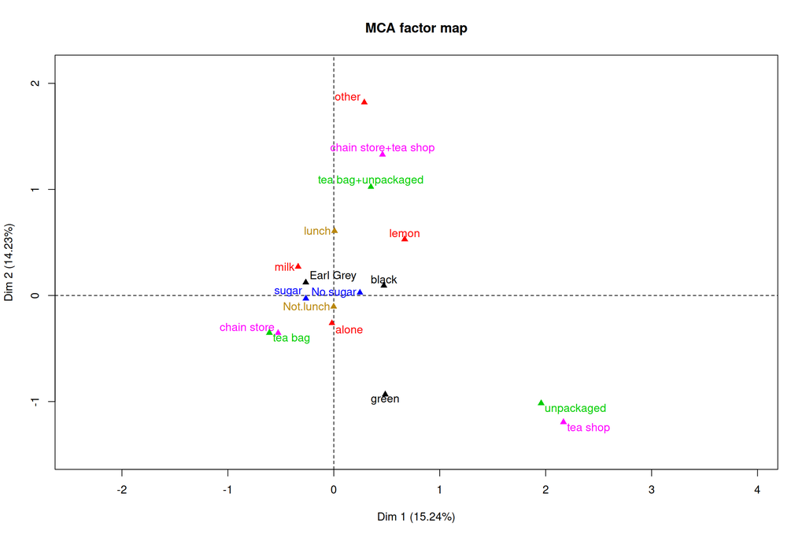

```r
# biplot
plot(mca, invisible=c("ind"), graph.type = "classic", habillage = "quali" )
```

From the plot, we can see that the majority of the variables are spread along the PC2, implying that PC2 is able to “stratify” most of the questions in the tea dataset.  
On the other hand, the categories **unpackaged** and **tea shop** are clearly spread on the right (positive) side of PC1.  
Drawing conclusions from this plot is not easy: what we can speculate is that PC1 is able to stratify those people that we can identify as “tea connoisseurs”: those who get tea at the tea shop usually know what they want and buy unpackaged; the other way around, people who are “casual” tea drinkers, and get tea from chain store they buy tea in a tea bag (both these varaibles are located on the negative side of the PC1).